# 3 Analysis

As with before, I always prefer reading the data from the url just in case I made some mistake in the previous step.

This plot gives us some insight on the variables of the dataset.

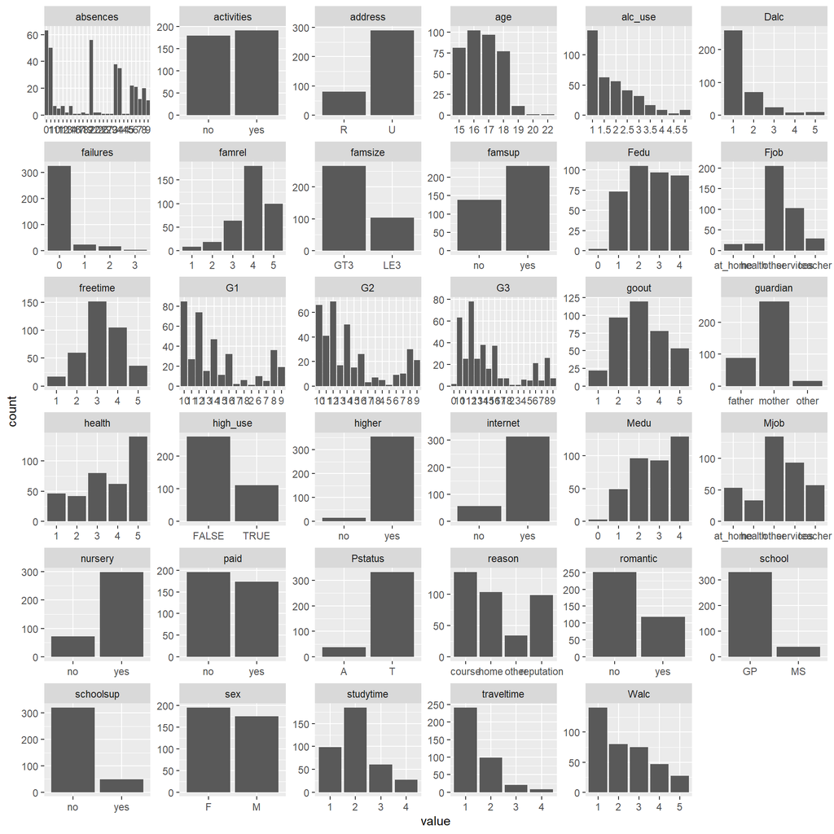

```r
library(tidyr); library(dplyr); library(ggplot2)
# draw a bar plot of each variable
gather(alc) %>% ggplot(aes(value)) + geom_bar() + facet_wrap("key", scales = "free")
```

From the previous plots we select “sex”, “absences”, “reason”, “traveltime”. My initial idea for selecting them is

sex: both the differences in males and females (I assume males drink more alcohol or feel more inclined to reporting it).

absences: maybe we could see some people who like to party more, or just have a more carefree lifestyle.

reason: the reasons could also reflect on the lifestyle

traveltime: perhaps the traveltime time could point to different wealth status, which I would think could also affect alcohol consumption.

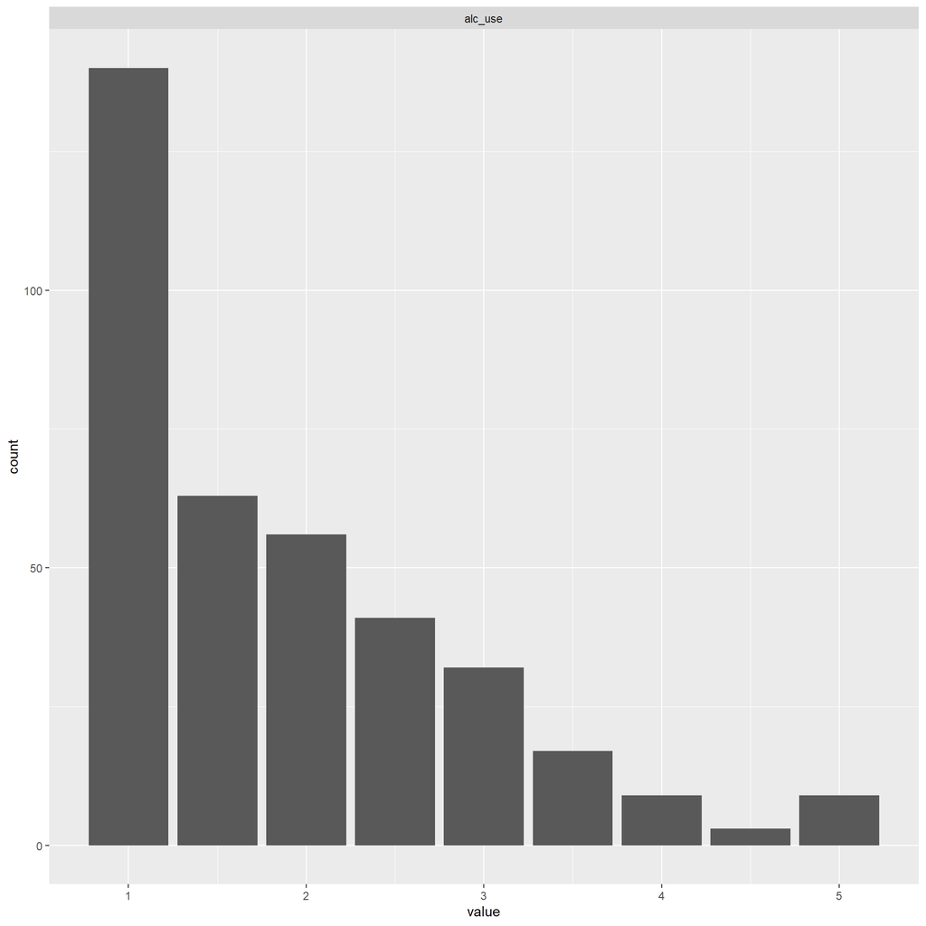

```r
# draw a bar plot for alc variable
alc %>% select(alc_use) %>% gather %>% ggplot(aes(value)) + geom_bar() + facet_wrap("key", scales = "free")
```

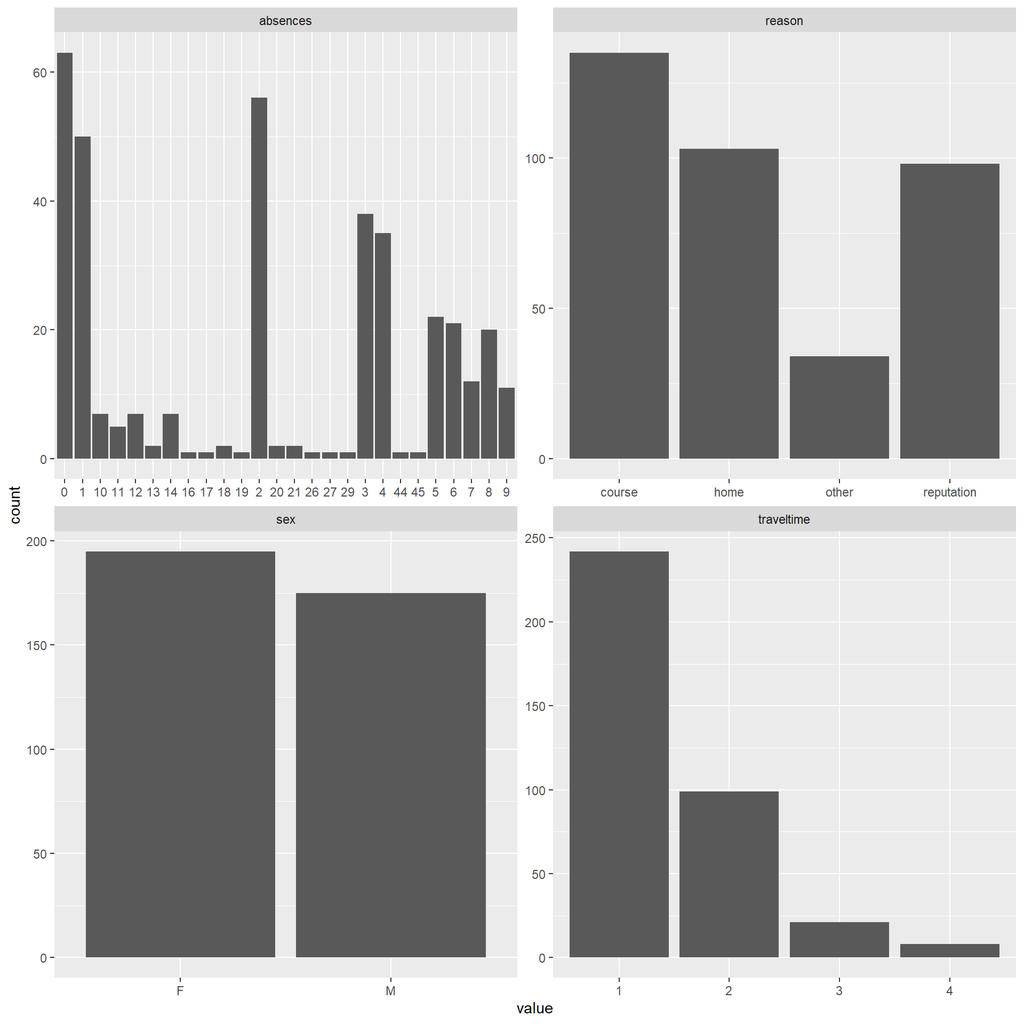

```r
# draw a bar plot of each variable
alc %>% select(sex, absences, reason, traveltime) %>% gather %>% ggplot(aes(value)) + geom_bar() + facet_wrap("key", scales = "free")
```

For comparing the multiple variables I decided to use the crosstable function. The first variable we look at is the sex. Both sexes have a rather considerable chi-square value, meaning that this variable seems indeed interesting for our modelling purposes.

If the formatting is broken, I suggest opening them in a new window. This order was selected due to the high number of elements of some variables.

```r
library(gmodels)
CrossTable(alc$sex, alc$alc_use)
```

```
##
##
##    Cell Contents
## |-------------------------|
## |                       N |
## | Chi-square contribution |
## |           N / Row Total |
## |           N / Col Total |
## |         N / Table Total |
## |-------------------------|
##
##
## Total Observations in Table:  370
##
##
##              | alc$alc_use
##      alc$sex |         1 |       1.5 |         2 |       2.5 |         3 |       3.5 |         4 |       4.5 |         5 | Row Total |
## -------------|-----------|-----------|-----------|-----------|-----------|-----------|-----------|-----------|-----------|-----------|
##            F |        87 |        41 |        26 |        25 |        11 |         3 |         1 |         0 |         1 |       195 |
##              |     2.367 |     1.831 |     0.418 |     0.532 |     2.040 |     3.964 |     2.954 |     1.581 |     2.954 |           |
##              |     0.446 |     0.210 |     0.133 |     0.128 |     0.056 |     0.015 |     0.005 |     0.000 |     0.005 |     0.527 |
##              |     0.621 |     0.651 |     0.464 |     0.610 |     0.344 |     0.176 |     0.111 |     0.000 |     0.111 |           |
##              |     0.235 |     0.111 |     0.070 |     0.068 |     0.030 |     0.008 |     0.003 |     0.000 |     0.003 |           |
## -------------|-----------|-----------|-----------|-----------|-----------|-----------|-----------|-----------|-----------|-----------|
##            M |        53 |        22 |        30 |        16 |        21 |        14 |         8 |         3 |         8 |       175 |
##              |     2.638 |     2.040 |     0.466 |     0.593 |     2.273 |     4.417 |     3.292 |     1.762 |     3.292 |           |
##              |     0.303 |     0.126 |     0.171 |     0.091 |     0.120 |     0.080 |     0.046 |     0.017 |     0.046 |     0.473 |
##              |     0.379 |     0.349 |     0.536 |     0.390 |     0.656 |     0.824 |     0.889 |     1.000 |     0.889 |           |
##              |     0.143 |     0.059 |     0.081 |     0.043 |     0.057 |     0.038 |     0.022 |     0.008 |     0.022 |           |
## -------------|-----------|-----------|-----------|-----------|-----------|-----------|-----------|-----------|-----------|-----------|
## Column Total |       140 |        63 |        56 |        41 |        32 |        17 |         9 |         3 |         9 |       370 |
##              |     0.378 |     0.170 |     0.151 |     0.111 |     0.086 |     0.046 |     0.024 |     0.008 |     0.024 |           |
## -------------|-----------|-----------|-----------|-----------|-----------|-----------|-----------|-----------|-----------|-----------|
##
##
```

A chi-square value of 0 would mean that the variables are completely independent. To my surprise, the highest consumption of alcohol seems to have a larger dependency to the lower absences. They seem to have some relation, just not what I expected.

```r
library(gmodels)
CrossTable(alc$absences, alc$alc_use)
```

```
##
##
##    Cell Contents
## |-------------------------|
## |                       N |
## | Chi-square contribution |
## |           N / Row Total |
## |           N / Col Total |
## |         N / Table Total |
## |-------------------------|
##
##
## Total Observations in Table:  370
##
##
##              | alc$alc_use
## alc$absences |         1 |       1.5 |         2 |       2.5 |         3 |       3.5 |         4 |       4.5 |         5 | Row Total |
## -------------|-----------|-----------|-----------|-----------|-----------|-----------|-----------|-----------|-----------|-----------|
##            0 |        31 |        10 |         9 |         6 |         4 |         3 |         0 |         0 |         0 |        63 |
##              |     2.152 |     0.049 |     0.030 |     0.138 |     0.385 |     0.004 |     1.532 |     0.511 |     1.532 |           |
##              |     0.492 |     0.159 |     0.143 |     0.095 |     0.063 |     0.048 |     0.000 |     0.000 |     0.000 |     0.170 |
##              |     0.221 |     0.159 |     0.161 |     0.146 |     0.125 |     0.176 |     0.000 |     0.000 |     0.000 |           |
##              |     0.084 |     0.027 |     0.024 |     0.016 |     0.011 |     0.008 |     0.000 |     0.000 |     0.000 |           |
## -------------|-----------|-----------|-----------|-----------|-----------|-----------|-----------|-----------|-----------|-----------|
##            1 |        18 |        10 |         9 |         5 |         6 |         2 |         0 |         0 |         0 |        50 |
##              |     0.045 |     0.260 |     0.271 |     0.053 |     0.649 |     0.038 |     1.216 |     0.405 |     1.216 |           |
##              |     0.360 |     0.200 |     0.180 |     0.100 |     0.120 |     0.040 |     0.000 |     0.000 |     0.000 |     0.135 |
##              |     0.129 |     0.159 |     0.161 |     0.122 |     0.188 |     0.118 |     0.000 |     0.000 |     0.000 |           |
##              |     0.049 |     0.027 |     0.024 |     0.014 |     0.016 |     0.005 |     0.000 |     0.000 |     0.000 |           |
## -------------|-----------|-----------|-----------|-----------|-----------|-----------|-----------|-----------|-----------|-----------|
##            2 |        24 |         8 |         8 |         3 |         6 |         2 |         3 |         0 |         2 |        56 |
##              |     0.373 |     0.247 |     0.027 |     1.656 |     0.276 |     0.128 |     1.969 |     0.454 |     0.299 |           |
##              |     0.429 |     0.143 |     0.143 |     0.054 |     0.107 |     0.036 |     0.054 |     0.000 |     0.036 |     0.151 |
##              |     0.171 |     0.127 |     0.143 |     0.073 |     0.188 |     0.118 |     0.333 |     0.000 |     0.222 |           |
##              |     0.065 |     0.022 |     0.022 |     0.008 |     0.016 |     0.005 |     0.008 |     0.000 |     0.005 |           |
## -------------|-----------|-----------|-----------|-----------|-----------|-----------|-----------|-----------|-----------|-----------|
##            3 |        21 |         6 |         4 |         4 |         1 |         0 |         1 |         0 |         1 |        38 |
##              |     3.049 |     0.034 |     0.533 |     0.011 |     1.591 |     1.746 |     0.006 |     0.308 |     0.006 |           |
##              |     0.553 |     0.158 |     0.105 |     0.105 |     0.026 |     0.000 |     0.026 |     0.000 |     0.026 |     0.103 |
##              |     0.150 |     0.095 |     0.071 |     0.098 |     0.031 |     0.000 |     0.111 |     0.000 |     0.111 |           |
```

[output cut: 124 more lines]

```
##              |     0.000 |     0.000 |     0.000 |     1.000 |     0.000 |     0.000 |     0.000 |     0.000 |     0.000 |     0.003 |
##              |     0.000 |     0.000 |     0.000 |     0.024 |     0.000 |     0.000 |     0.000 |     0.000 |     0.000 |           |
##              |     0.000 |     0.000 |     0.000 |     0.003 |     0.000 |     0.000 |     0.000 |     0.000 |     0.000 |           |
## -------------|-----------|-----------|-----------|-----------|-----------|-----------|-----------|-----------|-----------|-----------|
##           45 |         1 |         0 |         0 |         0 |         0 |         0 |         0 |         0 |         0 |         1 |
##              |     1.021 |     0.170 |     0.151 |     0.111 |     0.086 |     0.046 |     0.024 |     0.008 |     0.024 |           |
##              |     1.000 |     0.000 |     0.000 |     0.000 |     0.000 |     0.000 |     0.000 |     0.000 |     0.000 |     0.003 |
##              |     0.007 |     0.000 |     0.000 |     0.000 |     0.000 |     0.000 |     0.000 |     0.000 |     0.000 |           |
##              |     0.003 |     0.000 |     0.000 |     0.000 |     0.000 |     0.000 |     0.000 |     0.000 |     0.000 |           |
## -------------|-----------|-----------|-----------|-----------|-----------|-----------|-----------|-----------|-----------|-----------|
## Column Total |       140 |        63 |        56 |        41 |        32 |        17 |         9 |         3 |         9 |       370 |
##              |     0.378 |     0.170 |     0.151 |     0.111 |     0.086 |     0.046 |     0.024 |     0.008 |     0.024 |           |
## -------------|-----------|-----------|-----------|-----------|-----------|-----------|-----------|-----------|-----------|-----------|
##
##
```

For the reason it seems that mostly they seem independent. However, there are variables which show a higher score such as reputation and consumption 2.

```r
library(gmodels)
CrossTable(alc$reason, alc$alc_use)
```

```
##
##
##    Cell Contents
## |-------------------------|
## |                       N |
## | Chi-square contribution |
## |           N / Row Total |
## |           N / Col Total |
## |         N / Table Total |
## |-------------------------|
##
##
## Total Observations in Table:  370
##
##
##              | alc$alc_use
##   alc$reason |         1 |       1.5 |         2 |       2.5 |         3 |       3.5 |         4 |       4.5 |         5 | Row Total |
## -------------|-----------|-----------|-----------|-----------|-----------|-----------|-----------|-----------|-----------|-----------|
##       course |        53 |        26 |        18 |        12 |        12 |         7 |         3 |         1 |         3 |       135 |
##              |     0.072 |     0.395 |     0.290 |     0.585 |     0.009 |     0.102 |     0.025 |     0.008 |     0.025 |           |
##              |     0.393 |     0.193 |     0.133 |     0.089 |     0.089 |     0.052 |     0.022 |     0.007 |     0.022 |     0.365 |
##              |     0.379 |     0.413 |     0.321 |     0.293 |     0.375 |     0.412 |     0.333 |     0.333 |     0.333 |           |
##              |     0.143 |     0.070 |     0.049 |     0.032 |     0.032 |     0.019 |     0.008 |     0.003 |     0.008 |           |
## -------------|-----------|-----------|-----------|-----------|-----------|-----------|-----------|-----------|-----------|-----------|
##         home |        39 |        15 |        13 |        15 |        11 |         4 |         2 |         1 |         3 |       103 |
##              |     0.000 |     0.367 |     0.430 |     1.127 |     0.491 |     0.113 |     0.102 |     0.033 |     0.098 |           |
##              |     0.379 |     0.146 |     0.126 |     0.146 |     0.107 |     0.039 |     0.019 |     0.010 |     0.029 |     0.278 |
##              |     0.279 |     0.238 |     0.232 |     0.366 |     0.344 |     0.235 |     0.222 |     0.333 |     0.333 |           |
##              |     0.105 |     0.041 |     0.035 |     0.041 |     0.030 |     0.011 |     0.005 |     0.003 |     0.008 |           |
## -------------|-----------|-----------|-----------|-----------|-----------|-----------|-----------|-----------|-----------|-----------|
##        other |         9 |         4 |         5 |         5 |         3 |         4 |         1 |         1 |         2 |        34 |
##              |     1.161 |     0.553 |     0.004 |     0.403 |     0.001 |     3.804 |     0.036 |     1.903 |     1.664 |           |
##              |     0.265 |     0.118 |     0.147 |     0.147 |     0.088 |     0.118 |     0.029 |     0.029 |     0.059 |     0.092 |
##              |     0.064 |     0.063 |     0.089 |     0.122 |     0.094 |     0.235 |     0.111 |     0.333 |     0.222 |           |
##              |     0.024 |     0.011 |     0.014 |     0.014 |     0.008 |     0.011 |     0.003 |     0.003 |     0.005 |           |
## -------------|-----------|-----------|-----------|-----------|-----------|-----------|-----------|-----------|-----------|-----------|
##   reputation |        39 |        18 |        20 |         9 |         6 |         2 |         3 |         0 |         1 |        98 |
##              |     0.099 |     0.103 |     1.800 |     0.318 |     0.723 |     1.391 |     0.159 |     0.795 |     0.803 |           |
##              |     0.398 |     0.184 |     0.204 |     0.092 |     0.061 |     0.020 |     0.031 |     0.000 |     0.010 |     0.265 |
##              |     0.279 |     0.286 |     0.357 |     0.220 |     0.188 |     0.118 |     0.333 |     0.000 |     0.111 |           |
##              |     0.105 |     0.049 |     0.054 |     0.024 |     0.016 |     0.005 |     0.008 |     0.000 |     0.003 |           |
## -------------|-----------|-----------|-----------|-----------|-----------|-----------|-----------|-----------|-----------|-----------|
## Column Total |       140 |        63 |        56 |        41 |        32 |        17 |         9 |         3 |         9 |       370 |
##              |     0.378 |     0.170 |     0.151 |     0.111 |     0.086 |     0.046 |     0.024 |     0.008 |     0.024 |           |
## -------------|-----------|-----------|-----------|-----------|-----------|-----------|-----------|-----------|-----------|-----------|
##
##
```

As expected, there seem indeed to be some relationship between travel distance and alcohol consumption. We see that as the distance increases, the total score decreases.

```r
library(gmodels)
CrossTable(alc$traveltime, alc$alc_use)
```

```
##
##
##    Cell Contents
## |-------------------------|
## |                       N |
## | Chi-square contribution |
## |           N / Row Total |
## |           N / Col Total |
## |         N / Table Total |
## |-------------------------|
##
##
## Total Observations in Table:  370
##
##
##                | alc$alc_use
## alc$traveltime |         1 |       1.5 |         2 |       2.5 |         3 |       3.5 |         4 |       4.5 |         5 | Row Total |
## ---------------|-----------|-----------|-----------|-----------|-----------|-----------|-----------|-----------|-----------|-----------|
##              1 |        95 |        42 |        37 |        24 |        21 |        11 |         6 |         1 |         5 |       242 |
##                |     0.129 |     0.015 |     0.004 |     0.296 |     0.000 |     0.001 |     0.002 |     0.472 |     0.134 |           |
##                |     0.393 |     0.174 |     0.153 |     0.099 |     0.087 |     0.045 |     0.025 |     0.004 |     0.021 |     0.654 |
##                |     0.679 |     0.667 |     0.661 |     0.585 |     0.656 |     0.647 |     0.667 |     0.333 |     0.556 |           |
##                |     0.257 |     0.114 |     0.100 |     0.065 |     0.057 |     0.030 |     0.016 |     0.003 |     0.014 |           |
## ---------------|-----------|-----------|-----------|-----------|-----------|-----------|-----------|-----------|-----------|-----------|
##              2 |        40 |        16 |        17 |        14 |         4 |         4 |         1 |         1 |         2 |        99 |
##                |     0.172 |     0.044 |     0.271 |     0.837 |     2.431 |     0.066 |     0.823 |     0.048 |     0.069 |           |
##                |     0.404 |     0.162 |     0.172 |     0.141 |     0.040 |     0.040 |     0.010 |     0.010 |     0.020 |     0.268 |
##                |     0.286 |     0.254 |     0.304 |     0.341 |     0.125 |     0.235 |     0.111 |     0.333 |     0.222 |           |
##                |     0.108 |     0.043 |     0.046 |     0.038 |     0.011 |     0.011 |     0.003 |     0.003 |     0.005 |           |
## ---------------|-----------|-----------|-----------|-----------|-----------|-----------|-----------|-----------|-----------|-----------|
##              3 |         4 |         4 |         2 |         3 |         6 |         1 |         1 |         0 |         0 |        21 |
##                |     1.960 |     0.050 |     0.437 |     0.195 |     9.638 |     0.001 |     0.468 |     0.170 |     0.511 |           |
##                |     0.190 |     0.190 |     0.095 |     0.143 |     0.286 |     0.048 |     0.048 |     0.000 |     0.000 |     0.057 |
##                |     0.029 |     0.063 |     0.036 |     0.073 |     0.188 |     0.059 |     0.111 |     0.000 |     0.000 |           |
##                |     0.011 |     0.011 |     0.005 |     0.008 |     0.016 |     0.003 |     0.003 |     0.000 |     0.000 |           |
## ---------------|-----------|-----------|-----------|-----------|-----------|-----------|-----------|-----------|-----------|-----------|
##              4 |         1 |         1 |         0 |         0 |         1 |         1 |         1 |         1 |         2 |         8 |
##                |     1.357 |     0.096 |     1.211 |     0.886 |     0.137 |     1.088 |     3.333 |    13.482 |    16.750 |           |
##                |     0.125 |     0.125 |     0.000 |     0.000 |     0.125 |     0.125 |     0.125 |     0.125 |     0.250 |     0.022 |
##                |     0.007 |     0.016 |     0.000 |     0.000 |     0.031 |     0.059 |     0.111 |     0.333 |     0.222 |           |
##                |     0.003 |     0.003 |     0.000 |     0.000 |     0.003 |     0.003 |     0.003 |     0.003 |     0.005 |           |
## ---------------|-----------|-----------|-----------|-----------|-----------|-----------|-----------|-----------|-----------|-----------|
##   Column Total |       140 |        63 |        56 |        41 |        32 |        17 |         9 |         3 |         9 |       370 |
##                |     0.378 |     0.170 |     0.151 |     0.111 |     0.086 |     0.046 |     0.024 |     0.008 |     0.024 |           |
## ---------------|-----------|-----------|-----------|-----------|-----------|-----------|-----------|-----------|-----------|-----------|
##
##
```

## Logistic regression

Regarding the odds ratios, we have that a value of 1 would mean the two variables are independent. Larger than 1 means they are correlated and lower than 1 means they are negatively correlated. For our purposes I would argue that any value considerably away from 1 is useful for our model. After all, a strong indication of a value or the negation of that value would help guide the model. For our case, we see that sex indeed has a significantly larger than 1 odds ratio, with even its lower confidence interval above 1. Meaning a good correlation between it and our target. Absences on the other hand shows us that there is a consistent correlation, but the distance to 1 is much smaller. This was not shown as clearly in our previous metric. Travel time on the other hand shows a larger upper confidence interval, meaning that for some cases it does give us more information. The reason variable has the most interesting behavior in my opinion. Although before they had a high value for the Z-statistics, we now see that the odd ratio is not super good, but from their confidence intervals we see that they sometimes have a negative correlation and sometimes a positive one. I think this actually means they are not good predictive variables, as their relationship seems to change depending on the value. This would make learning the model, in my opinion, more complicated.

```r
# find the model with glm()
m <- glm(high_use ~ sex + absences + traveltime + reason, data = alc, family = "binomial")

# print out a summary of the model
summary(m)
```

```
##
## Call:
## glm(formula = high_use ~ sex + absences + traveltime + reason,
##     family = "binomial", data = alc)
##
## Coefficients:
##                  Estimate Std. Error z value Pr(>|z|)
## (Intercept)      -2.50233    0.38742  -6.459 1.05e-10 ***
## sexM              0.97973    0.25027   3.915 9.05e-05 ***
## absences          0.10076    0.02457   4.101 4.11e-05 ***
## traveltime        0.41903    0.16736   2.504   0.0123 *
## reasonhome        0.12618    0.30888   0.409   0.6829
## reasonother       0.89956    0.41784   2.153   0.0313 *
## reasonreputation -0.36535    0.33099  -1.104   0.2697
## ---
## Signif. codes:  0 '***' 0.001 '**' 0.01 '*' 0.05 '.' 0.1 ' ' 1
##
## (Dispersion parameter for binomial family taken to be 1)
##
##     Null deviance: 452.04  on 369  degrees of freedom
## Residual deviance: 401.49  on 363  degrees of freedom
## AIC: 415.49
##
## Number of Fisher Scoring iterations: 4
```

```r
# print out the coefficients of the model
coef(m)
```

```
##      (Intercept)             sexM         absences       traveltime
##       -2.5023266        0.9797277        0.1007637        0.4190261
##       reasonhome      reasonother reasonreputation
##        0.1261831        0.8995610       -0.3653526
```

```r
# compute odds ratios (OR)
OR <- coef(m) %>% exp

# compute confidence intervals (CI)
CI <- confint(m) %>% exp
# print out the odds ratios with their confidence intervals
cbind(OR, CI)
```

```
##                          OR     2.5 %    97.5 %
## (Intercept)      0.08189424 0.0373175 0.1710846
## sexM             2.66373089 1.6404768 4.3849742
## absences         1.10601531 1.0565900 1.1635523
## traveltime       1.52048007 1.0957873 2.1182805
## reasonhome       1.13448993 0.6171224 2.0781000
## reasonother      2.45852348 1.0792890 5.6012936
## reasonreputation 0.69395194 0.3583216 1.3181019
```

With our model we can now make predictions. For this case we assume a probability larger than 0.5 to be TRUE, and lower than that FALSE. The correct predictions is the left to right diagonal in our table, and the wrong predictions the diagonal from right to left. In total we had 89 wrong cases, out of 370 cases, leading us to a 0.24 loss. If we just guessed values, one might expect a 50% error rate. In that case, we are doing pretty good.

```r
# predict() the probability of high_use
probabilities <- predict(m, type = "response")

library(dplyr)
# add the predicted probabilities to 'alc'
alc <- mutate(alc, probability = probabilities)

# use the probabilities to make a prediction of high_use
alc <- mutate(alc, prediction = probability > 0.5)

# see the last ten original classes, predicted probabilities, and class predictions
select(alc, failures, absences, sex, high_use, probability, prediction) %>% tail(10)
```

```
## # A tibble: 10 × 6
##    failures absences sex   high_use probability prediction
##       <dbl>    <dbl> <chr> <lgl>          <dbl> <lgl>
##  1        0        3 M     FALSE          0.436 FALSE
##  2        1        0 M     FALSE          0.554 TRUE
##  3        1        7 M     TRUE           0.537 TRUE
##  4        0        1 F     FALSE          0.340 FALSE
##  5        0        6 F     FALSE          0.268 FALSE
##  6        1        2 F     FALSE          0.132 FALSE
##  7        0        2 F     FALSE          0.132 FALSE
##  8        0        3 F     FALSE          0.204 FALSE
##  9        0        4 M     TRUE           0.430 FALSE
## 10        0        2 M     TRUE           0.484 FALSE
```

```r
# tabulate the target variable versus the predictions
table(high_use = alc$high_use, prediction = alc$prediction)
```

```
##         prediction
## high_use FALSE TRUE
##    FALSE   248   11
##    TRUE     78   33
```

Since we noticed that the reason variable seems to be unreliable for the predictions, we try a new model without it. We actually have a lower score, having missed 91 values, meaning a 0.246 loss. This could be because at least some of the values actually contributed in some cases, meaning a net loss when not considering this variable.

```r
m <- glm(high_use ~ sex + absences + traveltime, data = alc, family = "binomial")

# predict() the probability of high_use
probabilities <- predict(m, type = "response")

library(dplyr)
# add the predicted probabilities to 'alc'
alc <- mutate(alc, probability = probabilities)

# use the probabilities to make a prediction of high_use
alc <- mutate(alc, prediction = probability > 0.5)

# see the last ten original classes, predicted probabilities, and class predictions
select(alc, failures, absences, sex, high_use, probability, prediction) %>% tail(10)
```

```
## # A tibble: 10 × 6
##    failures absences sex   high_use probability prediction
##       <dbl>    <dbl> <chr> <lgl>          <dbl> <lgl>
##  1        0        3 M     FALSE          0.417 FALSE
##  2        1        0 M     FALSE          0.347 FALSE
##  3        1        7 M     TRUE           0.515 TRUE
##  4        0        1 F     FALSE          0.177 FALSE
##  5        0        6 F     FALSE          0.345 FALSE
##  6        1        2 F     FALSE          0.137 FALSE
##  7        0        2 F     FALSE          0.137 FALSE
##  8        0        3 F     FALSE          0.207 FALSE
##  9        0        4 M     TRUE           0.441 FALSE
## 10        0        2 M     TRUE           0.492 FALSE
```

```r
# tabulate the target variable versus the predictions
table(high_use = alc$high_use, prediction = alc$prediction)
```

```
##         prediction
## high_use FALSE TRUE
##    FALSE   249   10
##    TRUE     81   30
```

## Cross-validation

```r
# define a loss function (average prediction error)
loss_func <- function(class, prob) {
  n_wrong <- abs(class - prob) > 0.5
  mean(n_wrong)
}

# compute the average number of wrong predictions in the (training) data
loss_func(class = alc$high_use, prob = alc$probability)
```

[output not shown]

```r
# K-fold cross-validation
library(boot)
cv <- cv.glm(data = alc, cost = loss_func, glmfit = m, K = 10)

# average number of wrong predictions in the cross validation
cv$delta[1]
```

```
## [1] 0.2432432
```